```r
knitr::opts_chunk$set(echo = TRUE, warning = FALSE, error = FALSE,message = FALSE)
```

```r
# les packages à installer

#install.packages("gtsummary")
#install.packages("janitor")
#install.packages("ggplot2")
#install.packages("webshot")
#install.packages("readxl")
#install.packages("gridExtra")
#install.packages("ggExtra")
#install.packages("flextable")
```

```r
library(gtsummary)
library(janitor)
library(dplyr)
library(gt)
library(ggplot2)
library(flextable)
#library(htmlwidgets)
library(webshot)
library(readxl)
library(knitr)
library(lubridate)
library(gridExtra)
library(ggExtra)
```

# 1. Partie 1

## 1.1. Préparation des données

### 1.1.1. Importation et mise en forme

#### 1.1.1.1. Importation de la base

```r
library(readxl)
getwd()
```

```
## [1] "C:/Users/SAMSON/Documents/AWOUTO_SAMSON_PROJET_R"
```

```r
projet <- read_excel("Base_Projet.xlsx")
```

#### 1.1.1.2. Nombre de lignes et de colonnes de la base projet

```r
nb_lignes <- nrow(projet)
nb_colonnes <- ncol(projet)
cat("Nombre de lignes (PME) :", nb_lignes, "\n")
```

```
## Nombre de lignes (PME) : 250
```

```r
cat("Nombre de colonnes (variables) :", nb_colonnes, "\n")
```

```
## Nombre de colonnes (variables) : 33
```

#### 1.1.1.3. Vérification des valeurs manquantes pour la variable key dans la base projet

```r
if (any(is.na(projet$key))) {
  cat("Il y a des valeurs manquantes pour la variable 'key'.\n")
  # Identifier les lignes avec des valeurs manquantes pour 'key'
  pme_manquantes <- projet$key[is.na(projet$key)]
  cat("Les PME concernées sont :", paste(pme_manquantes, collapse = ", "), "\n")
} else {
  cat("Il n'y a pas de valeurs manquantes pour la variable 'key'.\n")

}
```

```
## Il n'y a pas de valeurs manquantes pour la variable 'key'.
```

```
 De ce qui précède, on est certain que chaque les individus
 de la base de  données possède  un identifiant
```

### 1.1.2. Création de variables

#### 1.1.2.1. Renommage

```r
library(dplyr)


projet <- projet %>%
  dplyr::rename(region = q1,
         departement = q2,
         sexe = q23)
```

```r
# Création d'une base de donnée alternative pour préserver la bse initiale
Projet <- projet
```

#### 1.1.2.2. Création de la variable sexe_2

```r
projet <- projet %>%
  mutate(sexe_2 = factor(case_when(sexe == "Femme" ~ 1, TRUE ~ 0)))

# Créer un data.frame nommé langues
langues <- data.frame(projet %>%
  select(key, starts_with("q24a_")))
```

#### 1.1.2.3.Créeation d’une variable nommée “parle”

```r
langue <- langues %>%
  mutate(parle = rowSums(select(langues, starts_with("q24a_"))))
```

#### 1.1.2.3.Sélectionn exclusive des variables “key” et “parle”

```r
langues <- langue %>%
  select(key, parle)

# Fusionner les data.frames projet et langues
projet <- left_join(projet, langues, by = "key")
```

# 2. Statistiques Descriptives

## 2.1. Création des fonction

#### 2.1.1. première fonction univariée

Cette fonction permet de générer des tableuax d’une variables donnée dans une base de données

```r
library(knitr)
library(kableExtra)

univarie_1 <- function(variable, base_de_donnees = "") {
  # Calculer la fréquence absolue
  freq_absolue <- table(variable)

  # Calculer la fréquence relative avec deux chiffres après la virgule
  freq_relative <- round(prop.table(freq_absolue), 2)

  # Créer le tableau de distribution
  tableau <- data.frame(Modalités = as.character(names(freq_absolue)),
                        Effectif = as.vector(freq_absolue),
                        Fréquence = as.vector(freq_relative))

  # Calculer le total des fréquences absolues
  total_freq_absolue <- sum(freq_absolue)

  # Ajouter la ligne du total
  total_row <- c("Total", total_freq_absolue, 1)
  tableau <- rbind(tableau, total_row)

  # Afficher le tableau de distribution avec kableExtra
  knitr::kable(tableau, align = "c", caption = "Tableau de distribution des fréquences") %>%
    kable_styling(bootstrap_options = "striped", full_width = FALSE) %>%
    add_header_above(c(" ", "Fréquences" = 2)) %>%
    row_spec(nrow(tableau), bold = TRUE)
}
```

#### 2.1.1.deuxième fonction univariée

Cette fonction permet de générer un graphque en barre ou un diagramme circulaire en fonction de l’option qu’aurait chosis l’utilisateu. On a en effet l’option barreet l’option *cercle*(diagramme circulaire) et *barre*(diagramme en barre)

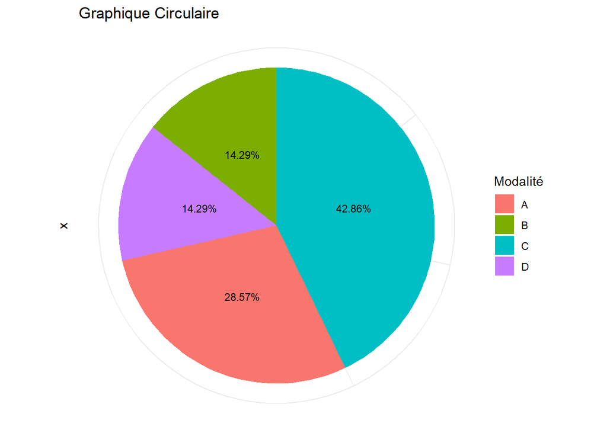

```r
library(ggplot2)

univarié_graphique<- function(variable, type_graphique = "barres") {
  # Calculer la fréquence absolue
  freq_absolue <- table(variable)

  # Calculer la fréquence relative en pourcentage avec deux chiffres après la virgule
  freq_relative <- prop.table(freq_absolue) * 100

  # Créer un dataframe à partir des fréquences absolues et relatives
  df <- data.frame(Modalité = as.character(names(freq_absolue)),
                   Fréquence_Absolue = as.vector(freq_absolue),
                   Fréquence_Relative = as.vector(freq_relative))

  # Formatage des fréquences relatives avec deux chiffres après la virgule
  df$Fréquence_Relative <- paste0(format(round(df$Fréquence_Relative, 2), nsmall = 2), "%")

  # Créer le graphique en barres avec des couleurs variées
  if (type_graphique == "barres") {
    ggplot(df, aes(x = Modalité, y = Fréquence_Absolue, fill = Modalité)) +
      geom_bar(stat = "identity") +
      geom_text(aes(label = Fréquence_Relative), vjust = -0.5, size = 3) + # Ajout des fréquences relatives
      labs(title = "Graphique en Barres", x = "Modalité", y = "Fréquence Absolue") +
      theme_minimal() +
      scale_fill_hue(name = "Modalité")
  } else if (type_graphique == "cercle") {
    # Créer le graphique circulaire avec des couleurs variées
    ggplot(df, aes(x = "", y = Fréquence_Relative, fill = Modalité)) +
      geom_bar(stat = "identity", width = 1) +
      geom_text(aes(label = Fréquence_Relative), position = position_stack(vjust = 0.5), size = 3) + # Ajout des fréquences relatives
      coord_polar("y", start = 0) +
      labs(title = "Graphique Circulaire", fill = "Modalité") +
      theme_minimal() +
      theme(axis.title.x=element_blank(),
            axis.text.x=element_blank(),
            axis.ticks.x=element_blank()) +
      scale_fill_hue(name = "Modalité")
  } else {
    cat("Type de graphique non reconnu. Veuillez spécifier 'barres' ou 'cercle'.")
  }
}

# Exemple d'utilisation
donnees <- c("A", "A", "B", "C", "C", "C", "D")
univarié_graphique(donnees, type_graphique = "cercle")
```

#### 2.1.3. Création de la fonction bivariée

la fonction bivariée est nommée tableau_croise et prend en argument deux variables ,puis retourne un *tableau croisé*

```r
### fonction bivariée: Fonction pour calculer les statistiques usuelles d'une variable quantitative
tableau_croise <- function(var1, var2) {
  # Calcul du tableau croisé
  tab <- table(var1, var2)

  # Ajout des totaux par ligne et par colonne
  tab_with_totals <- addmargins(tab, 1, FUN = list(Total = sum))
  tab_with_totals <- addmargins(tab_with_totals, 2, FUN = list(Total = sum))

  # Renommer les dimensions pour une meilleure lisibilité
  dimnames(tab_with_totals)[[1]][dim(tab_with_totals)[1]] <- "Total"
  dimnames(tab_with_totals)[[2]][dim(tab_with_totals)[2]] <- "Total"

  return(tab_with_totals)



}
```

#### 2.1.4. LA REPARTITION DES PROPORTION SUIVANTS LES VARIABLES DONNES

##### 2.1.4.0 Recodage de certaines variables d’intérêt

```
Dans cette partie nous avons trouvé judicuex de renommer les variables avec des     noms familiers pour uen lecture facile des statsitiques qui seront générées.
```

```r
#recodons les variables importantes:
# Renommer les variables q1, q2 et q23
projet <- projet %>%
  dplyr::rename(    "Niveau d’instruction" = q25,
                   "Statut juridique" =q12,
                  "propriétaire ou locataire" = q81)
```

##### 2.1.4.1 Repartition des PME selon le sexe

```r
# repartition du sexe
univarie_1(projet$sexe, projet)
```

Tableau de distribution des fréquences

| Modalités | Fréquences Effectif | Fréquences Fréquence |
| --- | --- | --- |
| Femme | 191 | 0.76 |
| Homme | 59 | 0.24 |
| Total | 250 | 1 |

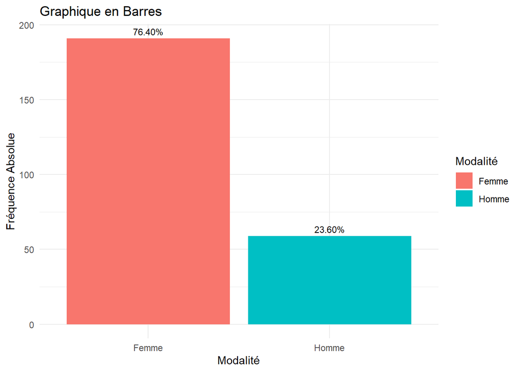

```r
univarié_graphique(projet$sexe , "barres")
```

Du graphique ci-dessus , on note que les femmes sont les personnes les plus nombresues dans l’échantillon prise pour les études soit 76% des PME contre 24% pour les hommes

##### 2.1.4.2 Repartition des PME selon le Niveau d’instruction

```r
univarie_1(projet$`Niveau d’instruction`, projet)
```

Tableau de distribution des fréquences

| Modalités | Fréquences Effectif | Fréquences Fréquence |
| --- | --- | --- |
| Aucun niveau | 79 | 0.32 |
| Niveau primaire | 56 | 0.22 |
| Niveau secondaire | 74 | 0.3 |
| Niveau Superieur | 41 | 0.16 |
| Total | 250 | 1 |

[figure not shown]

```r
univarié_graphique(projet$`Niveau d’instruction` , "cercle")
```

De ce graphique on retient essentiellement que les propriétaires des plantations ou des champs n’ont pas en général pas pu effectuer des études secondaires contre seulement 16% qui ont pu entamer un au moins un pas à l’université

##### 2.1.4.3 Repartition des PME selon le propriétaire/locataire

```r
univarie_1(projet$`propriétaire ou locataire`, projet)
```

Tableau de distribution des fréquences

| Modalités | Fréquences Effectif | Fréquences Fréquence |
| --- | --- | --- |
| Locataire | 24 | 0.1 |
| Propriétaire | 226 | 0.9 |
| Total | 250 | 1 |

[figure not shown]

```r
univarié_graphique(projet$`propriétaire ou locataire` , "cercle")
```

Comme on pouvait l’attendre les PME( soit 90%) possèdent les surfaces cultivées où ils travaiillent.

##### 2.1.4.5 Repartition des PME selon le Statut juridique le statut juridique et le sexe

```r
tableau_croise(projet$`Statut juridique`, projet$sexe)
```

```
##              var2
## var1          Femme Homme Total
##   Association     3     3     6
##   GIE           149    30   179
##   Informel       32     6    38
##   SA              1     6     7
##   SARL            2    11    13
##   SUARL           4     3     7
##   Total         191    59   250
```

##### 2.1.4.6 Repartition des PME selon la variable Propriétaire/locataire suivant le sexe

```r
tableau_croise(projet$`propriétaire ou locataire`, projet$sexe)
```

```
##               var2
## var1           Femme Homme Total
##   Locataire       16     8    24
##   Propriétaire   175    51   226
##   Total          191    59   250
```

##### 2.1.4.8 Repartition des PME selon le Statut juridique et le sexe

```r
tableau_croise(projet$`Statut juridique`, projet$sexe)
```

```
##              var2
## var1          Femme Homme Total
##   Association     3     3     6
##   GIE           149    30   179
##   Informel       32     6    38
##   SA              1     6     7
##   SARL            2    11    13
##   SUARL           4     3     7
##   Total         191    59   250
```

## 2.2. Statistiques descriptives sur les autres variables

### 2.2.1 Création d’une variable nommée filiere: Celle ci donne la culture principale des PME

```r
projet <- Projet %>% mutate(filiere = if_else(filiere_1 ==1,
                  "Arachide",if_else(filiere_2 ==1,
                  "Anarchade",if_else(filiere_3 ==1,
                  "Mangue",if_else(filiere_4 ==1,"Riz","")))))
# On crée là le nombre de filière pour chaque PME en faisant la somme des
#           variables filières
projet <- projet %>% mutate(nb_filiere = filiere_1 + filiere_2 + filiere_3 + filiere_4)

# On affiche la répartiton des PME par nbre de filière avec gtsummary
tableau_1 <- projet["nb_filiere"]%>%
  tbl_summary(label = nb_filiere ~ "Nombre de filière",
  )
tableau_1
```

| **Characteristic** | **N = 250**<sup>1</sup> |
| --- | --- |
| Nombre de filière |  |
| 1 | 171 (68%) |
| 2 | 59 (24%) |
| 3 | 19 (7.6%) |
| 4 | 1 (0.4%) |

<sup>1</sup> n (%)

### 2.2.2# Créons une fonction pour les tableaux croisés par filière et sexe

# Ici aussi pour faire analyser la variable sexe par filière d’activité , nous avons procéder à l’élaborationdes tableaux gtsummary avec strate.Par suite , nous avons décidé de définir une fonction qui facilitera les sorties des résultats sur chaque filière. L’objectif est de fusionner en lignes le tableau créer ppur chaque variable par filière et ensuite merger en colonne pour les filières.

```r
theme_gtsummary_compact(set_theme = TRUE, font_size = NULL)
      #Créons une fonction pour les tableaux croisés par filière et sexe


tabl_fil =function(base_donnee, num_var_filiere_, nom_filiere,lab_var,num_var){

                         ### TABLEAU CROISE

  tableau <- base_donnee %>%
  dplyr::select(sexe, q25, q12, q81, names(base_donnee[num_var_filiere_])
                ) %>%
  gtsummary::tbl_strata(
    strata = names(base_donnee[num_var_filiere_]),
    .tbl_fun = ~ .x %>%
      gtsummary::tbl_cross(
        row = names(base_donnee[num_var]),
        col = sexe,
        percent = "cell",
        margin = NULL,
        #statistic = ~ "{p}% ({n})",
        #digits = ~ 2,
        label = list(names(base_donnee[num_var]) ~ as.character(lab_var),
                     sexe ~ "sexe du responsable")
        ) %>% add_p() %>%
      bold_labels() %>%
      italicize_levels(),

    ## préciser comment combiner les tableaux de chaque groupe. Par défaut,
    ## il combine avec "tbl_merge"
    .combine_with = "tbl_merge",
    .header = "{strata}"
    )%>%
    ## mise en forme de l'entête du tableau
   modify_header(
      list(
        all_stat_cols(stat_0 = FALSE) ~ "**{level}** (n={n}, {style_percent(p)}%)"
      )
     ) %>%
    modify_column_hide(c(stat_1_1,stat_2_1,p.value_1))
  return(tableau)
}

tab_prop_1 <- tabl_fil(projet,23,"Arachide","Propriétaire/Locataire",
                       which(names(projet)=="q81"))
tab_niv_1 <- tabl_fil(projet,23,"Arachide","Niveau d'instruction",
                      which(names(projet)=="q25"))
tab_stat_1 <- tabl_fil(projet,23,"Arachide","Statut juridique",
                       which(names(projet)=="q81"))

tab_fil_1 <- gtsummary::tbl_stack(list(tab_prop_1, tab_niv_1,tab_stat_1))


tab_prop_2 <- tabl_fil(projet,24,"Anarchade","Propriétaire/Locataire",
                       which(names(projet)=="q81"))
tab_niv_2 <- tabl_fil(projet,24,"Anarchade","Niveau d'instruction",
                      which(names(projet)=="q25"))
tab_stat_2 <- tabl_fil(projet,24,"Anarchade","Statut juridique",
                       which(names(projet)=="q81"))

tab_fil_2 <- gtsummary::tbl_stack(list(tab_prop_2, tab_niv_2,tab_stat_2))


tab_prop_3 <- tabl_fil(projet,25,"Arachide","Propriétaire/Locataire",
                       which(names(projet)=="q81"))
tab_niv_3 <- tabl_fil(projet,25,"Arachide","Niveau d'instruction",
                      which(names(projet)=="q25"))
tab_stat_3 <- tabl_fil(projet,25,"Arachide","Statut juridique",
                       which(names(projet)=="q81"))

tab_fil_3 <- gtsummary::tbl_stack(list(tab_prop_3, tab_niv_3,tab_stat_3))

tab_prop_4 <- tabl_fil(projet,26,"Arachide","Propriétaire/Locataire",
                       which(names(projet)=="q81"))
tab_niv_4 <- tabl_fil(projet,26,"Arachide","Niveau d'instruction",
                      which(names(projet)=="q25"))
tab_stat_4 <- tabl_fil(projet,26,"Arachide","Statut juridique",
                       which(names(projet)=="q81"))

tab_fil_4 <- gtsummary::tbl_stack(list(tab_prop_4, tab_niv_4,tab_stat_4))

tab_crois <- gtsummary::tbl_merge(
  list(tab_fil_1,tab_fil_2,tab_fil_3,tab_fil_4),
  tab_spanner = c("**Arachide**", "**Anacarde**","**Mangue**","**Riz**")
  ## intitulé des groupes de tableau associés
)
tab_crois
```

|  | **Arachide** **Femme** (n=93, 86%) | **Arachide** **Homme** (n=15, 14%) | **Arachide** **p-value**<sup>1</sup> | **Anacarde** **Femme** (n=40, 66%) | **Anacarde** **Homme** (n=21, 34%) | **Anacarde** **p-value**<sup>1</sup> | **Mangue** **Femme** (n=68, 76%) | **Mangue** **Homme** (n=21, 24%) | **Mangue** **p-value**<sup>1</sup> | **Riz** **Femme** (n=77, 84%) | **Riz** **Homme** (n=15, 16%) | **Riz** **p-value**<sup>1</sup> |
| --- | --- | --- | --- | --- | --- | --- | --- | --- | --- | --- | --- | --- |
| Propriétaire/Locataire |  |  | 0.4 |  |  | 0.2 |  |  | 0.7 |  |  | >0.9 |
| Locataire | 9 (8.3%) | 3 (2.8%) |  | 3 (4.9%) | 4 (6.6%) |  | 8 (9.0%) | 3 (3.4%) |  | 8 (8.7%) | 1 (1.1%) |  |
| Propriétaire | 84 (78%) | 12 (11%) |  | 37 (61%) | 17 (28%) |  | 60 (67%) | 18 (20%) |  | 69 (75%) | 14 (15%) |  |
| Niveau d'instruction |  |  | 0.3 |  |  | <0.001 |  |  | 0.004 |  |  | <0.001 |
| Aucun niveau | 38 (35%) | 5 (4.6%) |  | 12 (20%) | 1 (1.6%) |  | 22 (25%) | 4 (4.5%) |  | 10 (11%) | 1 (1.1%) |  |
| Niveau primaire | 20 (19%) | 3 (2.8%) |  | 15 (25%) | 2 (3.3%) |  | 20 (22%) | 4 (4.5%) |  | 26 (28%) | 0 (0%) |  |
| Niveau secondaire | 30 (28%) | 4 (3.7%) |  | 9 (15%) | 6 (9.8%) |  | 21 (24%) | 4 (4.5%) |  | 28 (30%) | 4 (4.3%) |  |
| Niveau Superieur | 5 (4.6%) | 3 (2.8%) |  | 4 (6.6%) | 12 (20%) |  | 5 (5.6%) | 9 (10%) |  | 13 (14%) | 10 (11%) |  |
| Statut juridique |  |  | 0.4 |  |  | 0.2 |  |  | 0.7 |  |  | >0.9 |
| Locataire | 9 (8.3%) | 3 (2.8%) |  | 3 (4.9%) | 4 (6.6%) |  | 8 (9.0%) | 3 (3.4%) |  | 8 (8.7%) | 1 (1.1%) |  |
| Propriétaire | 84 (78%) | 12 (11%) |  | 37 (61%) | 17 (28%) |  | 60 (67%) | 18 (20%) |  | 69 (75%) | 14 (15%) |  |

<sup>1</sup> Fisher’s exact test

#### 2.2.3 Type de filière par région

Pour une vue assez bonne de la répartition on se limiter à l’analyse de la vriable region suivant les différentes filières. C’est de ça dont il est question dans ce code :

```r
theme_gtsummary_compact(set_theme = TRUE, font_size = NULL)

## Format de la sortie
theme_gtsummary_printer(
  print_engine = "flextable",
  #c("gt", "kable", "kable_extra", "flextable", "huxtable", "tibble"),
  set_theme = TRUE
)
               # Créons le tableau 1 pour arachide

tbl_1 <- projet %>%select(region,filiere_1) %>%
  gtsummary::tbl_summary(
    include = c(region,filiere_1),
    by = filiere_1
  ,label = list(region ~ "Région"))%>%
  add_overall()%>%
  bold_labels() %>%
  italicize_levels()%>%modify_column_hide(c(stat_0,stat_1))

               # Créons le tableau 2 pour anacharde

tbl_2 <- projet %>%select(region,filiere_2) %>%
  gtsummary::tbl_summary(
    include = c(region,filiere_2),
    by = filiere_2
  ,label = list(region ~ "Région"))%>%
  add_overall()%>%
  bold_labels() %>%
  italicize_levels()%>%modify_column_hide(c(stat_0,stat_1))

               # Créons le tableau 3 pour mangue
tbl_3 <- projet %>%select(region,filiere_3) %>%
  gtsummary::tbl_summary(
    include = c(region,filiere_3),
    by = filiere_3
  ,label = list(region ~ "Région"))%>%
  add_overall()%>%
  bold_labels() %>%
  italicize_levels()%>%modify_column_hide(c(stat_0,stat_1))

               # Créons le tableau 4 pour riz

tbl_4 <- projet %>%select(region,filiere_4) %>%
  gtsummary::tbl_summary(
    include = c(region,filiere_4),
    by = filiere_4
  ,label = list(region ~ "Région"))%>%
  add_overall()%>%
  bold_labels() %>%
  italicize_levels()%>%modify_column_hide(c(stat_0,stat_1))

               #F les 4 tableaux ci-dessus en un seul tableau

gtsummary::tbl_merge(
  list(tbl_1,tbl_2,tbl_3,tbl_4),
  tab_spanner =  c("Arachide", "Anacarde","Mangue","Riz")
  ## intitulé des groupes de tableau associés
)
```

| Characteristic | Arachide 1, N = 1081 | Anacarde 1, N = 611 | Mangue 1, N = 891 | Riz 1, N = 921 |
| --- | --- | --- | --- | --- |
| Région |  |  |  |  |
| Dakar | 0 (0%) | 1 (1.6%) | 0 (0%) | 1 (1.1%) |
| Diourbel | 33 (31%) | 0 (0%) | 1 (1.1%) | 0 (0%) |
| Fatick | 12 (11%) | 21 (34%) | 3 (3.4%) | 4 (4.3%) |
| Kaffrine | 8 (7.4%) | 0 (0%) | 5 (5.6%) | 1 (1.1%) |
| Kaolack | 20 (19%) | 0 (0%) | 7 (7.9%) | 4 (4.3%) |
| Kolda | 1 (0.9%) | 5 (8.2%) | 0 (0%) | 4 (4.3%) |
| Saint-Louis | 1 (0.9%) | 0 (0%) | 42 (47%) | 0 (0%) |
| Sédhiou | 0 (0%) | 3 (4.9%) | 0 (0%) | 3 (3.3%) |
| Thiès | 27 (25%) | 0 (0%) | 25 (28%) | 32 (35%) |
| Ziguinchor | 6 (5.6%) | 31 (51%) | 6 (6.7%) | 43 (47%) |

1n (%)

```r
theme_gtsummary_compact(set_theme = TRUE, font_size = NULL)

## Format de la sortie
theme_gtsummary_printer(
  print_engine = "flextable",
  #c("gt", "kable", "kable_extra", "flextable", "huxtable", "tibble"),
  set_theme = TRUE
)
               # Créons le tableau 1 pour arachide

tbl_1 <- projet %>%select(q81,filiere_1) %>%
  gtsummary::tbl_summary(
    include = c(q81,filiere_1),
    by = filiere_1
  ,label = list(q81 ~ "STATUT JURIDIQUE"))%>%
  add_overall()%>%
  bold_labels() %>%
  italicize_levels()%>%modify_column_hide(c(stat_0,stat_1))

               # Créons le tableau 2 pour anacharde

tbl_2 <- projet %>%select(q81,filiere_2) %>%
  gtsummary::tbl_summary(
    include = c(q81,filiere_2),
    by = filiere_2
  ,label = list(q81 ~ "STATUT JURIDIQUE"))%>%
  add_overall()%>%
  bold_labels() %>%
  italicize_levels()%>%modify_column_hide(c(stat_0,stat_1))

               # Créons le tableau 3 pour mangue
tbl_3 <- projet %>%select(q81,filiere_3) %>%
  gtsummary::tbl_summary(
    include = c(q81,filiere_3),
    by = filiere_3
  ,label = list(q81 ~ "STATUT JURIDIQUE"))%>%
  add_overall()%>%
  bold_labels() %>%
  italicize_levels()%>%modify_column_hide(c(stat_0,stat_1))

               # Créons le tableau 4 pour riz

tbl_4 <- projet %>%select(q81,filiere_4) %>%
  gtsummary::tbl_summary(
    include = c(q81,filiere_4),
    by = filiere_4
  ,label = list(q81~ "STATUT JURIDIQUE"))%>%
  add_overall()%>%
  bold_labels() %>%
  italicize_levels()%>%modify_column_hide(c(stat_0,stat_1))

               #Mergeons les 4 tableaux ci-dessus en un seul tableau

gtsummary::tbl_merge(
  list(tbl_1,tbl_2,tbl_3,tbl_4),
  tab_spanner =  c("Arachide", "Anacarde","Mangue","Riz")
  ## intitulé des groupes de tableau associés
)
```

| Characteristic | Arachide 1, N = 1081 | Anacarde 1, N = 611 | Mangue 1, N = 891 | Riz 1, N = 921 |
| --- | --- | --- | --- | --- |
| STATUT JURIDIQUE |  |  |  |  |
| Locataire | 12 (11%) | 7 (11%) | 11 (12%) | 9 (9.8%) |
| Propriétaire | 96 (89%) | 54 (89%) | 78 (88%) | 83 (90%) |

1n (%)

Cettr sectione est important en ce sens qu’il permet de manipuler le facteur temps dans notre base de données on peut en effet jouer ou consulter le temps pour apprécier certaines singularités dans une base de données.

On peut alors commencer comme suite:

```r
#Calculer la durée de l’entretien et indiquer la durée moyenne de l’entretien
#                     par enquêteur.

          #Créons d'abord la colonne durée de l'entretien

projet <- projet %>%
  mutate(duree_enquete = interval(today,submissiondate) %>% as.duration())

#     Moyenne du temps d'un entretien

vue_date <-projet %>% group_by(duree_enquete) %>% summarise(
  Duree_Moyenne = mean(duree_enquete))
print(head(vue_date))
```

```
## # A tibble: 6 × 2
##   duree_enquete         Duree_Moyenne
##   <Duration>                    <dbl>
## 1 47463s (~13.18 hours)         47463
## 2 49318s (~13.7 hours)          49318
## 3 49915s (~13.87 hours)         49915
## 4 52658s (~14.63 hours)         52658
## 5 53344s (~14.82 hours)         53344
## 6 55886s (~15.52 hours)         55886
```

### 2.2.6. Traitement sur les date

Création des colonnes mois, jour, heure, minutes et temps mis avant de soumettre en minutes donne un apperçu plus simplifié de l’agrégation du temps associé à la période d’enquête

```r
projet$submissiondate <- as.POSIXct(projet$submissiondate)

# Ajouter les variables pour le jour, l'heure, la minute, le mois de l'entretien et la durée de l'entretien
projet <- projet %>%
  mutate( mois_entretien = format(submissiondate, "%m"),
         jour_entretien = format(submissiondate, "%d"),
         heure_entretien = format(submissiondate, "%H"),
         minute_entretien = format(submissiondate, "%M"),
         duree_entretien = as.numeric(difftime(submissiondate, start, units = "mins")))
print(head(projet))
```

```
## # A tibble: 6 × 41
##   key   region departement sexe    q24 q24a_1 q24a_2 q24a_3 q24a_4 q24a_5 q24a_6
##   <chr> <chr>  <chr>       <chr> <dbl>  <dbl>  <dbl>  <dbl>  <dbl>  <dbl>  <dbl>
## 1 uuid… Diour… Bambey      Femme    65      0      1      0      1      0      0
## 2 uuid… Thiès  Mbour       Femme    52      1      1      0      0      1      0
## 3 uuid… Thiès  Mbour       Femme    65      1      1      0      0      0      0
## 4 uuid… Thiès  Mbour       Femme    38      1      1      0      0      1      0
## 5 uuid… Zigui… Bignona     Homme    40      1      1      1      0      0      1
## 6 uuid… Zigui… Oussouye    Femme    43      1      1      1      0      0      0
## # ℹ 30 more variables: q24a_7 <dbl>, q24a_9 <dbl>, q24a_10 <dbl>, q25 <chr>,
## #   q26 <dbl>, q12 <chr>, q14b <chr>, q16 <chr>, q17 <chr>, q19 <chr>,
## #   q20 <chr>, filiere_1 <dbl>, filiere_2 <dbl>, filiere_3 <dbl>,
## #   filiere_4 <dbl>, q8 <chr>, q81 <chr>, gps_menlatitude <dbl>,
## #   gps_menlongitude <dbl>, submissiondate <dttm>, start <dttm>, today <dttm>,
## #   filiere <chr>, nb_filiere <dbl>, duree_enquete <Duration>,
## #   mois_entretien <chr>, jour_entretien <chr>, heure_entretien <chr>, …
```

# ### 2.2.7.création de fonction d’extration conditionnée par une date

```r
library(dplyr)

extraire_soumissions_avant_date <- function(base, date_limite) {
  # Convertir la variable submissiondate en un objet de date/heure
  base$submissiondate <- as.POSIXct(base$submissiondate)

  # Extraire les soumissions avant la date limite
  soumissions_avant_date <- base %>%
    filter(submissiondate < date_limite)

  return(soumissions_avant_date)
}
```

```r
date_limite <- as.POSIXct("2021-06-05")
soumissions_avant_date <- extraire_soumissions_avant_date(projet, date_limite)

# Vérifier les soumissions extraites
head(soumissions_avant_date)
```

| key | region | departement | sexe | q24 | q24a_1 | q24a_2 | q24a_3 | q24a_4 | q24a_5 | q24a_6 | q24a_7 | q24a_9 | q24a_10 | q25 | q26 | q12 | q14b | q16 | q17 | q19 | q20 | filiere_1 | filiere_2 | filiere_3 | filiere_4 | q8 | q81 | gps_menlatitude | gps_menlongitude | … |
| --- | --- | --- | --- | --- | --- | --- | --- | --- | --- | --- | --- | --- | --- | --- | --- | --- | --- | --- | --- | --- | --- | --- | --- | --- | --- | --- | --- | --- | --- | --- |
| uuid:0ac18b64-7d85-4bb9-a842-698ac79909af | Thiès | Mbour | Femme | 65 | 1 | 1 | 0 | 0 | 0 | 0 | 0 | 0 | 0 | Niveau primaire | 5 | GIE | Non | Non | NA | Etat moyen | Oui | 1 | 0 | 1 | 0 | Tansformation d'autres céréales | Propriétaire | 14.39813 | -16.95576 | … |
| uuid:ac177870-001c-4ada-8747-c22ffe4e4596 | Ziguinchor | Bignona | Homme | 40 | 1 | 1 | 1 | 0 | 0 | 1 | 0 | 0 | 0 | Niveau secondaire | 20 | GIE | Oui | Oui | Bon état | NA | Oui | 0 | 0 | 0 | 1 | Autre a preciser | Propriétaire | 13.04763 | -16.61266 | … |
| uuid:74e608ca-a37e-47e3-8b22-e1e4bd51fa44 | Ziguinchor | Ziguinchor | Homme | 33 | 1 | 0 | 0 | 0 | 0 | 0 | 0 | 0 | 1 | Niveau Superieur | 5 | SUARL | Oui | Oui | Bon état | NA | Non | 0 | 1 | 0 | 0 | Transformation de la noix de cajoux | Locataire | 12.55944 | -16.23227 | … |
| uuid:23fc2818-318e-466d-ae28-ea93b5e59958 | Thiès | Thiès | Femme | 45 | 0 | 1 | 0 | 0 | 0 | 0 | 0 | 0 | 0 | Aucun niveau | 25 | GIE | Non | Oui | Bon état | NA | Oui | 1 | 0 | 0 | 0 | Transformation de l'arachide | Propriétaire | 14.81549 | -16.66208 | … |
| uuid:3784c36d-52ed-473e-a3e5-089c47a2f13a | Sédhiou | Goudomp | Homme | 47 | 1 | 0 | 0 | 0 | 0 | 1 | 1 | 0 | 0 | Niveau secondaire | 19 | GIE | Non | Oui | Bon état | NA | Oui | 0 | 1 | 0 | 0 | Transformation de la noix de cajoux | Propriétaire | 12.55572 | -15.78302 | … |
| uuid:7a87ce3f-ad2f-4ddc-9ba8-3c863ba80104 | Ziguinchor | Ziguinchor | Homme | 54 | 0 | 1 | 0 | 0 | 1 | 1 | 0 | 1 | 1 | Niveau Superieur | 25 | SUARL | Non | Oui | Bon état | NA | Non | 0 | 1 | 0 | 0 | Transformation de la noix de cajoux | Propriétaire | 12.55537 | -16.32282 | … |